# Practical Machine Learning Project

Julio J. Melero

15 de diciembre de 2014

## Introduction

The goal of this project is to use data from several sensors situated on the belt, forearm, arm, and dumbbell of 6 participants to quantify how well they are doing a particular activity. The used sensors ared 9 degrees of freedom Razor inertial measurement units (IMU), which provide three-axes acceleration, gyroscope and magnetometer data at a joint sampling rate of 45 Hz. The prediction will be accomplished by training a model on the registered data. I will use a random forest classifier algorimth for this project.

I will use the Caret package for almost all the tasks to be peformed on the data, subsetting, training and cross-validation.

```r
library(caret)
```

## Data loading and preprocessing

First, I will load the training data and subset it into a training and a testing set. In this way, I will have a test set where I can estimate the performance of the model befor using it to classify the actual test set.

```r
# Global training data
setwd("~/Dropbox/MachineLearning/Course project")
training_data <- read.table("pml-training.csv", header = TRUE, sep = ",",na.strings=c("",".","NA"))
# The first 7 columns are useless for our project
training_data1 <- training_data[, -seq(from = 1, to = 7, by = 1)]
# seed random number
set.seed(987654)
# test subset: 40% of training data
test_num_data <- createDataPartition(y = training_data1$classe, p = 0.4, list = F)
test_data <- training_data1[test_num_data, ]
# training subset: 60% of training data
train_data <- training_data1[-test_num_data, ]
```

```r
# function to determine percentage of variable filling
filled_pct <- function(x) {
    n <- length(x)
    nas <- sum(is.na(x))
    return(100*(n - nas)/n)
}
# Calculate variable percentage filling
var_pct_fill<-apply(train_data, 2, filled_pct)
# Remove variables not filled at least 95% of observations
final_train_data <- train_data[, var_pct_fill > 95]
final_test_data<-test_data[,var_pct_fill>95]
```

## Prediction algorithm

The prediction algorithm has to be selected according to the stated problem. After filtering the data and discarding meaningless variables, there remain 52 variables to fit the model. Moreover, possible relations and interactions betweeen variables are unknown. With this conditions, one of the best possible models are Random Forests (RF). They are very well suited to handle a big number of variables. Besides that, RF can be used to estimate variable importance allowing to discard some of the inputs in the model. Cross-validation and probability outputs for classification are other important properties of RF.

## Cross-validation and determination of the inputs of the algorithm

```r
var_imp_number<-createDataPartition(y = final_train_data$classe, p = 0.2, list = F)
var_imp_data<-final_train_data[var_imp_number,]
imp_model <- train(classe ~ ., data = var_imp_data, method = "rf")
```

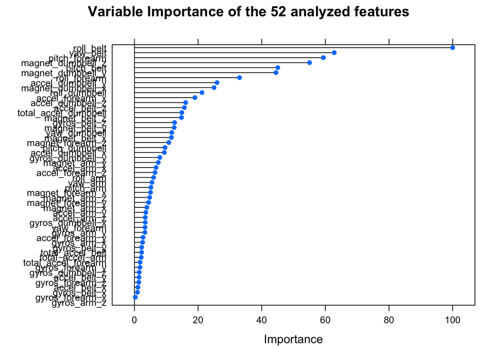

```r
var_imp<-varImp(imp_model)
plot(var_imp,main = "Variable Importance of the 52 analyzed features")
```

```r
imp_level <- quantile(var_imp$importance[, 1], 0.50)
imp_filter <- var_imp$importance[, 1] >= imp_level
reduced_final_train_data<- final_train_data[, imp_filter]
rfModel <- train(classe ~ ., data = reduced_final_train_data, method = "rf",trControl=trainControl(method='cv'), number=5, allowParallel=TRUE)
```

## Results

Once the model is fitted, cross-validation is performed with the testing dataset. Confusion matrix is used for getting all the relevant information.

```r
prediction <- predict(rfModel, final_test_data)
mt<-confusionMatrix(prediction,final_test_data$classe)
mt
```

```
## Confusion Matrix and Statistics
##
##           Reference
## Prediction    A    B    C    D    E
##          A 2222   22    0    0    0
##          B    5 1485   18    0    2
##          C    5   11 1343   16    5
##          D    0    1    8 1270    5
##          E    0    0    0    1 1431
##
## Overall Statistics
##
##                Accuracy : 0.9874
##                  95% CI : (0.9847, 0.9897)
##     No Information Rate : 0.2843
##     P-Value [Acc > NIR] : < 2.2e-16
##
##                   Kappa : 0.984
##  Mcnemar's Test P-Value : NA
##
## Statistics by Class:
##
##                      Class: A Class: B Class: C Class: D Class: E
## Sensitivity            0.9955   0.9776   0.9810   0.9868   0.9917
## Specificity            0.9961   0.9961   0.9943   0.9979   0.9998
## Pos Pred Value         0.9902   0.9834   0.9732   0.9891   0.9993
## Neg Pred Value         0.9982   0.9946   0.9960   0.9974   0.9981
## Prevalence             0.2843   0.1935   0.1744   0.1639   0.1838
## Detection Rate         0.2831   0.1892   0.1711   0.1618   0.1823
## Detection Prevalence   0.2859   0.1924   0.1758   0.1636   0.1824
## Balanced Accuracy      0.9958   0.9868   0.9876   0.9923   0.9958
```

Unbiased estimate of the random forest’s out-of-sample error rate is 1.26 %.

## Prediction with the real test data

Here, the model is applied to the real test data and the proposed function is used to generate the needed text files.

```r
testing_data <- read.table("pml-testing.csv", header = TRUE, sep = ",",na.strings=c("",".","NA"))
answers <- predict(rfModel,testing_data)

pml_write_files = function(x){
  n = length(x)
  for(i in 1:n){
    filename = paste0("problem_id_",i,".txt")
    write.table(x[i],file=filename,quote=FALSE,row.names=FALSE,col.names=FALSE)
  }
}

pml_write_files(answers)
```